# Introduction to Neural Networks

## 17 October 2023

# Let's review

Consider the following two plots:

[figure not shown]

Which of the two data sets shown above has the higher Mean Squared Error (MSE)?

# Reducing Loss

[figure not shown]

- A Machine Learning model is trained by starting with an initial guess for the weights and bias and iteratively adjusting those guesses until learning the weights and bias with the lowest possible loss
  - These values are commonly randomly initialized
  - Can also be 0-initialized
  - Other strategies exist, but we won't go too far into them
- We iterate until overall loss stops changing, or changes extremely slowly
  - When this happens, we say that the model has **converged**

# Gradients

- The gradient of a function, denoted $\nabla f$, is the vector of partial derivatives with respect to all of the independent variables
  - $\nabla f$ points in the direction of **greatest increase** of the function
  - $-\nabla f$ points in the direction of **greatest decrease** of the function
- The number of dimensions in the vector is equal to the number of variables in the formula for $f$
- A gradient is a vector, so it has both a **direction** and a **magnitude**

# Gradient Descent

[figure not shown]

# Learning Rate

- Gradient descent algorithms multiply the gradient by a scalar known as the **learning rate** (also called **step size**) to determine the next point
- Learning rate is what's known as a model **hyperparameter**
  - Hyperparameters refer broadly to ways to alter how a model trains, without affecting its formal structure
- This is one of the most important hyperparameters to optimize since too small or too large of a value can prevent your model from converging

[figure not shown]

# Introducing Neural Networks

Recall the equation for a multiple regression from last week:

$$ y_{i} = \beta_{0} + \beta_{1}x_{i,1}+\beta_{2}x_{i,2} + \ldots + \beta_{n}x_{i,n} $$

Simplified to $Y=X\beta+\epsilon$

A single neuron in a neural network is fundamentally similar:

[figure not shown]

A **neural network** is then just a composition of these individual neurons:

[figure not shown]

# Structure of a Network

[figure not shown]

# Activation Functions

[figure not shown]

# Sigmoid Activation

The following sigmoid activation function converts the weighted sum to a value between 0 and 1. It is equivalent to the logit function of a logistic regression that we reviewed last week:

[figure not shown]

# ReLU Activation

The following **rectified linear unit** activation function (or **ReLU**, for short) often works a little better than a smooth function like the sigmoid, while also being significantly easier to compute.

$$ F(x)=max(0,x) $$

[figure not shown]

# Starting with TensorFlow

[figure not shown]

# Imperative programming

```python
import tensorflow as tf

a = tf.constant(5)
b = tf.constant(3)
c = a * b

print(c)
```

```
tf.Tensor(15, shape=(), dtype=int32)
```

# Sequential API

```
model = tf.keras.Sequential()
model.add(layers.Dense(32, activation='relu', input_shape=(784,)))
model.add(layers.Dense(32, activation='relu'))
model.add(layers.Dense(32, activation='softmax'))
```

Jam-packed with the methods you know and love. Smash hits include:

```
model.summary()
model.fit()
model.predict()
model.predict_on_batch()
```

# A Regression in TensorFlow

```
model = tf.keras.models.Sequential()
model.add(
    tf.keras.layers.Dense(
        units=1,
        input_shape=(1,)
))
model.compile(
    optimizer=tf.keras.optimizers.experimental.RMSprop(learning_rate=my_learning_rate),
    loss="mean_squared_error",
    metrics=[tf.keras.metrics.RootMeanSquaredError()]
)
```

```python
training_df = pd.read_csv("https://download.mlcc.google.com/mledu-datasets/california_housing_train.csv")
training_df["median_house_value"] /= 1000.0
training_df.head()
```

|  | longitude | latitude | housing_median_age | total_rooms | total_bedrooms | population | households | median_income | median_house_value |
| --- | --- | --- | --- | --- | --- | --- | --- | --- | --- |
| 0 | -114.31 | 34.19 | 15.0 | 5612.0 | 1283.0 | 1015.0 | 472.0 | 1.4936 | 66.9 |
| 1 | -114.47 | 34.40 | 19.0 | 7650.0 | 1901.0 | 1129.0 | 463.0 | 1.8200 | 80.1 |
| 2 | -114.56 | 33.69 | 17.0 | 720.0 | 174.0 | 333.0 | 117.0 | 1.6509 | 85.7 |
| 3 | -114.57 | 33.64 | 14.0 | 1501.0 | 337.0 | 515.0 | 226.0 | 3.1917 | 73.4 |
| 4 | -114.57 | 33.57 | 20.0 | 1454.0 | 326.0 | 624.0 | 262.0 | 1.9250 | 65.5 |

```python
# The following variables are the hyperparameters.
learning_rate = 0.01
epochs = 30
batch_size = 30

my_feature = "total_rooms"
my_label="median_house_value"
my_model = None

# Invoke the functions.
my_model = build_model(learning_rate)
my_model.summary()
```

```
Model: "sequential"
_________________________________________________________________
 Layer (type)                Output Shape              Param #
=================================================================
 dense (Dense)               (None, 1)                 2

=================================================================
Total params: 2 (8.00 Byte)
Trainable params: 2 (8.00 Byte)
Non-trainable params: 0 (0.00 Byte)
_________________________________________________________________
```

```python
weight, bias, epochs, rmse = train_model(
    my_model, training_df,
    my_feature, my_label,
    epochs, batch_size)
```

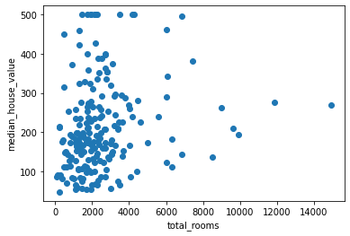

```python
plot_the_model(weight, bias, my_feature, my_label)
```

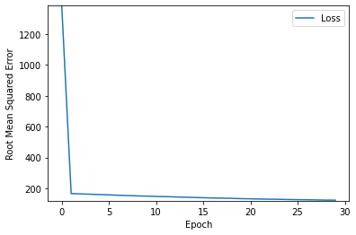

```
The learned weight for your model is 0.0232
The learned bias for your model is 132.5321
```

```python
plot_the_loss_curve(epochs, rmse)
print("\nThe learned weight for your model is %.4f" % weight)
print("The learned bias for your model is %.4f\n" % bias )
```

```python
predict_house_values(10, my_feature, my_label)
```

```
feature   label          predicted
  value   value          value
          in thousand$   in thousand$
--------------------------------------
 1960     53             178
 3400     92             211
 3677     69             218
 2202     62             184
 2403     80             188
 5652    295             263
 3318    500             209
 2552    342             192
 1364    118             164
 3468    128             213
```